# Mengatasi Ketidakstasioneran

```r
library(ggplot2)
library(tsibble)
library(tseries)
library(MASS)
library(readxl)
library(ggpubr)
```

## Input Data

```r
library(readxl)
dataiklim <- read_excel("C:/mpdwbos/mpdw/PERTEMUAN 2/dataiklimharian.xlsx", sheet = "iklim")
head(dataiklim)
```

```
## # A tibble: 6 × 2
##   Periode TAVG
##     <dbl> <chr>
## 1       1 27.2
## 2       2 27.1
## 3       3 27.8
## 4       4 26.9
## 5       5 28.4
## 6       6 27.4
```

```r
print("Struktur Data")
```

```
## [1] "Struktur Data"
```

```r
str(dataiklim)
```

```
## tibble [125 × 2] (S3: tbl_df/tbl/data.frame)
##  $ Periode: num [1:125] 1 2 3 4 5 6 7 8 9 10 ...
##  $ TAVG   : chr [1:125] "27.2" "27.1" "27.8" "26.9" ...
```

```r
print("Contoh Data")
```

```
## [1] "Contoh Data"
```

```r
head(dataiklim, 10)
```

```
## # A tibble: 10 × 2
##    Periode TAVG
##      <dbl> <chr>
##  1       1 27.2
##  2       2 27.1
##  3       3 27.8
##  4       4 26.9
##  5       5 28.4
##  6       6 27.4
##  7       7 26.4
##  8       8 26.6
##  9       9 25.5
## 10      10 27
```

```r
# Konversi data TAVG menjadi numerik dan cek missing values
tavg_data <- as.numeric(dataiklim$TAVG)
# Cek missing values
print("Missing values")
```

```
## [1] "Missing values"
```

```r
print(paste("Jumlah total observasi:", length(tavg_data)))
```

```
## [1] "Jumlah total observasi: 125"
```

```r
print(paste("Jumlah missing values (NA):", sum(is.na(tavg_data))))
```

```
## [1] "Jumlah missing values (NA): 1"
```

```r
print(paste("Persentase missing values:", round(sum(is.na(tavg_data))/length(tavg_data)*100, 2), "%"))
```

```
## [1] "Persentase missing values: 0.8 %"
```

```r
# Posisi missing values
if(sum(is.na(tavg_data)) > 0) {
  na_positions <- which(is.na(tavg_data))
  print("Posisi missing values:")
  print(na_positions)
}
```

```
## [1] "Posisi missing values:"
## [1] 112
```

## Cleaning Data

```r
tavg_clean <- na.omit(tavg_data)
print(paste("jumlah observasi:", length(tavg_clean)))
```

```
## [1] "jumlah observasi: 124"
```

```r
tavg_ts <- ts(tavg_clean)

print("Statistik Deskriptif")
```

```
## [1] "Statistik Deskriptif"
```

```r
print(paste("Jumlah observasi:", length(tavg_ts)))
```

```
## [1] "Jumlah observasi: 124"
```

```r
print(paste("Mean TAVG:", round(mean(tavg_ts), 4)))
```

```
## [1] "Mean TAVG: 27.0653"
```

```r
print(paste("Variance TAVG:", round(var(tavg_ts), 4)))
```

```
## [1] "Variance TAVG: 0.8346"
```

```r
print(paste("Min TAVG:", round(min(tavg_ts), 4)))
```

```
## [1] "Min TAVG: 23.4"
```

```r
print(paste("Max TAVG:", round(max(tavg_ts), 4)))
```

```
## [1] "Max TAVG: 28.9"
```

## Partisi Data menjadi Train dan Test

```r
# Tentukan proporsi data training (misalnya 80% untuk train, 20% untuk test)
train_size <- floor(0.8 * length(tavg_clean))

# Bagi data
tavg_train <- tavg_clean[1:train_size]
tavg_test <- tavg_clean[(train_size + 1):length(tavg_clean)]

# Konversi ke time series
tavg_train_ts <- ts(tavg_train)
tavg_test_ts <- ts(tavg_test)

print("=== INFORMASI PARTISI DATA ===")
```

```
## [1] "=== INFORMASI PARTISI DATA ==="
```

```r
print(paste("Total observasi:", length(tavg_clean)))
```

```
## [1] "Total observasi: 124"
```

```r
print(paste("Data Training:", length(tavg_train_ts), "observasi"))
```

```
## [1] "Data Training: 99 observasi"
```

```r
print(paste("Data Testing:", length(tavg_test_ts), "observasi"))
```

```
## [1] "Data Testing: 25 observasi"
```

```r
print(paste("Proporsi Train/Test:", round(train_size/length(tavg_clean)*100, 2), "% / ",
            round((length(tavg_clean)-train_size)/length(tavg_clean)*100, 2), "%"))
```

```
## [1] "Proporsi Train/Test: 79.84 % /  20.16 %"
```

## Visualisasi Partisi Data

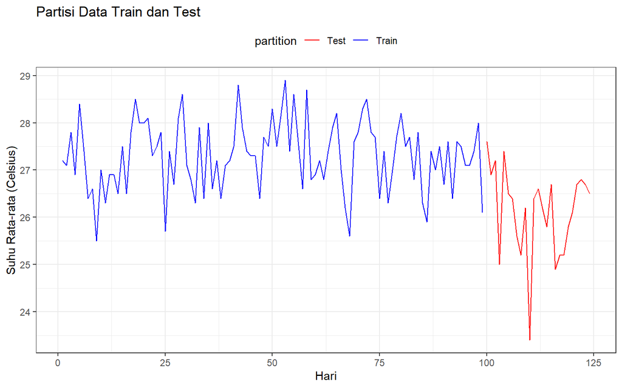

```r
# Buat dataframe untuk plotting
df_partisi <- data.frame(
  index = 1:length(tavg_clean),
  value = tavg_clean,
  partition = c(rep("Train", train_size), rep("Test", length(tavg_test)))
)

plot_partisi <- ggplot(df_partisi, aes(x = index, y = value, color = partition)) +
  geom_line() +
  scale_color_manual(values = c("Train" = "blue", "Test" = "red")) +
  theme_bw() +
  xlab("Hari") +
  ylab("Suhu Rata-rata (Celsius)") +
  ggtitle("Partisi Data Train dan Test") +
  theme(legend.position = "top")

print(plot_partisi)
```

## Analisis Stasioneritas Data Train

## 1. Plot Time Series Data Train

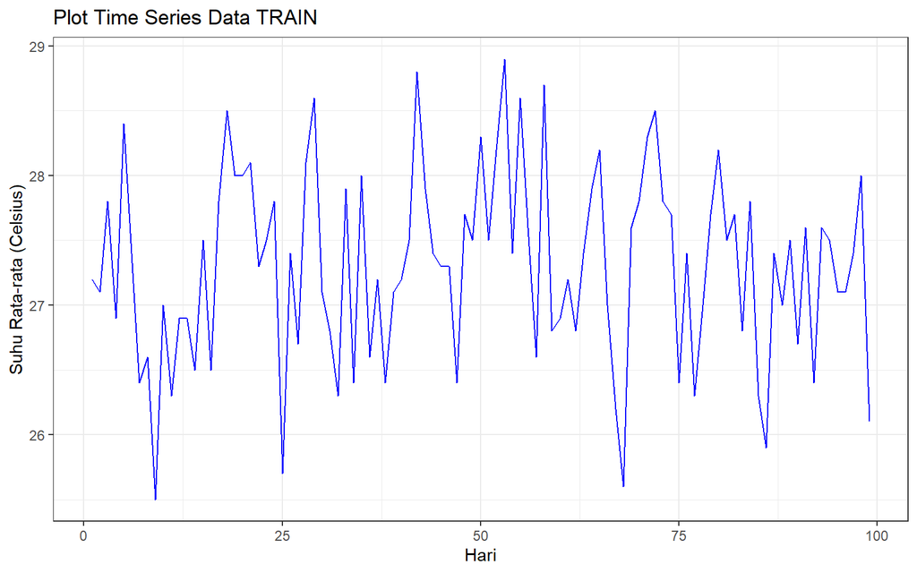

```r
tavg_train_df <- data.frame(
  index = 1:length(tavg_train_ts),
  value = as.numeric(tavg_train_ts)
)

plot_train <- ggplot(tavg_train_df, aes(x = index, y = value)) +
  geom_line(color = "blue") +
  theme_bw() +
  xlab("Hari") +
  ylab("Suhu Rata-rata (Celsius)") +
  ggtitle("Plot Time Series Data TRAIN")
print(plot_train)
```

**1. Karakteristik Visual:** Data suhu rata-rata harian (TAVG) menunjukkan pola fluktuasi yang konsisten sepanjang 99 hari observasi training. Suhu bergerak dalam rentang 25.5°C hingga 29°C dengan mean di sekitar 27°C.

**A. Stasioner dalam rataan:**

Data tidak menunjukkan trend naik atau turun yang jelas. Mean tetap konstan di sekitar 27°C dari awal hingga akhir periode. Fluktuasi terjadi secara seimbang di atas dan di bawah garis horizontal mean Kesimpulan: Data stasioner dalam rataan karena tidak ada pergeseran sistematis mean

**B. Stasioner dalam ragam:**

Amplitudo fluktuasi relatif konsisten sepanjang periode Tidak ada pola “funnel shape” atau heteroskedastisitas Variabilitas di awal periode (~3°C) sama dengan di akhir periode (~2.5-3°C) Kesimpulan: Data stasioner dalam ragam karena volatilitas konstan

## 2. Plot ACF Data Train

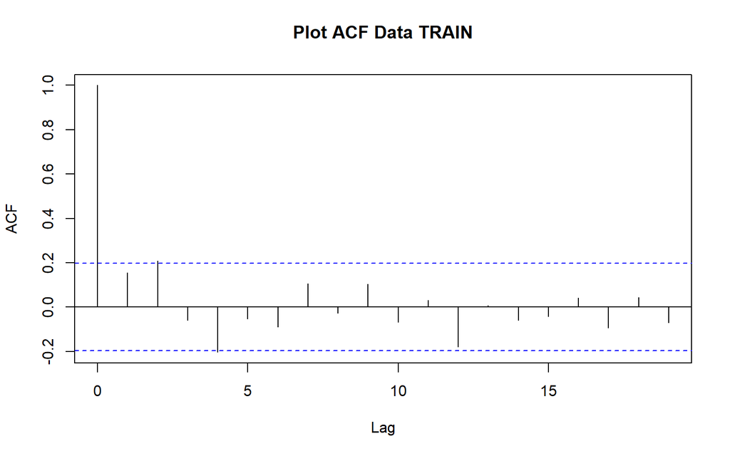

```r
par(mfrow = c(1, 1))
acf(tavg_train_ts, main = "Plot ACF Data TRAIN")
```

### **Karakteristik ACF:**

**A. Lag 0:**

- ACF = 1.0 (sempurna, karena korelasi data dengan dirinya sendiri)

**C. Lag 4 ke atas:**

- ACF turun cepat dan berada dalam batas kepercayaan (tidak signifikan)
- ACF berfluktuasi di sekitar nol dengan pola acak
- Beberapa lag menunjukkan ACF negatif ringan tapi tidak signifikan

## 3. Uji ADF Data Train

**Hipotesis:**

- H₀ (Null Hypothesis): Data tidak stasioner
- H₁ (Alternative Hypothesis): Data stasioner

```r
adf_train <- adf.test(tavg_train_ts)
print("=== HASIL UJI ADF DATA TRAIN ===")
```

```
## [1] "=== HASIL UJI ADF DATA TRAIN ==="
```

```r
print(adf_train)
```

```
##
##  Augmented Dickey-Fuller Test
##
## data:  tavg_train_ts
## Dickey-Fuller = -4.5529, Lag order = 4, p-value = 0.01
## alternative hypothesis: stationary
```

```r
if(adf_train$p.value < 0.05) {
  print("Kesimpulan ADF: Data TRAIN STASIONER dalam rataan (p-value < 0.05)")
} else {
  print("Kesimpulan ADF: Data TRAIN TIDAK STASIONER dalam rataan (p-value >= 0.05)")
}
```

```
## [1] "Kesimpulan ADF: Data TRAIN STASIONER dalam rataan (p-value < 0.05)"
```

**A. Statistik Uji:**

- Dickey-Fuller statistic = -4.5529
- Nilai ini sangat negatif dan jauh dari 0
- Semakin negatif nilai DF, semakin kuat bukti stasioneritas

**B. P-value:**

- **p-value = 0.01** (sangat kecil, < 0.05)
- P-value yang sangat kecil ini memberikan **bukti sangat kuat untuk menolak H₀**

**C. Lag Order:**

- Lag order = 4 dipilih otomatis oleh algoritma ADF

### **Kesimpulan Uji ADF:**

Tolak H₀ dengan sangat kuat. Data train stasioner dalam rataan (p-value = 0.01 < 0.05).

- Mean data tidak bergeser seiring waktu
- Tidak ada trend deterministik atau stokastik
- Data dapat langsung digunakan untuk pemodelan tanpa transformasi differencing

## 4. Plot Box-Cox Data Train

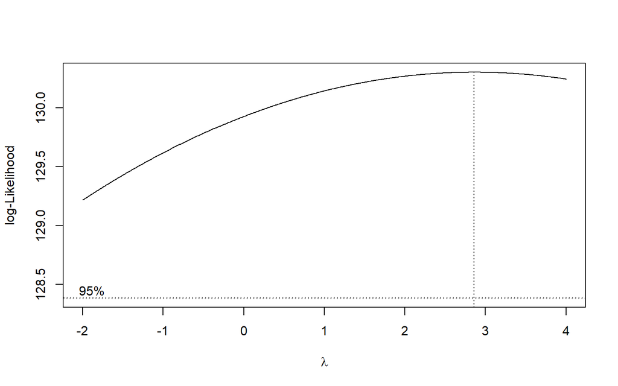

```r
# Pastikan data positif untuk Box-Cox
if(min(tavg_train_ts) <= 0) {
  tavg_train_positive <- tavg_train_ts - min(tavg_train_ts) + 1
  print("Data train digeser agar positif untuk analisis Box-Cox")
} else {
  tavg_train_positive <- tavg_train_ts
}

index_train <- seq(1:length(tavg_train_positive))

# Box-Cox transformation
bc_train <- boxcox(tavg_train_positive ~ index_train, lambda = seq(-2, 4, by = 0.01))
```

```r
# Nilai lambda optimum
lambda_train_opt <- bc_train$x[which.max(bc_train$y)]
print(paste("Lambda optimum (Train):", round(lambda_train_opt, 3)))
```

```
## [1] "Lambda optimum (Train): 2.86"
```

```r
# Selang kepercayaan 95% untuk lambda
ci_lambda_train <- bc_train$x[bc_train$y > max(bc_train$y) - 0.5 * qchisq(0.95, 1)]
ci_lower_train <- min(ci_lambda_train)
ci_upper_train <- max(ci_lambda_train)

print(paste("Selang kepercayaan 95% lambda (Train): [",
            round(ci_lower_train, 3), ",", round(ci_upper_train, 3), "]"))
```

```
## [1] "Selang kepercayaan 95% lambda (Train): [ -2 , 4 ]"
```

```r
if(ci_lower_train <= 1 && ci_upper_train >= 1) {
  print("Kesimpulan Box-Cox: Data TRAIN STASIONER dalam ragam (selang memuat 1)")
} else {
  print("Kesimpulan Box-Cox: Data TRAIN TIDAK STASIONER dalam ragam (selang tidak memuat 1)")
}
```

```
## [1] "Kesimpulan Box-Cox: Data TRAIN STASIONER dalam ragam (selang memuat 1)"
```

### **Karakteristik Plot:**

Plot menampilkan kurva log-likelihood untuk berbagai nilai lambda transformasi Box-Cox dalam rentang -2 hingga 4.

**A. Bentuk Kurva:**

- Kurva **smooth dan berbentuk parabola terbalik**
- Kurva naik dari lambda = -2, mencapai puncak di sekitar lambda = 2.86, lalu turun menuju lambda = 4

**B. Lambda Optimum:**

- **λ_opt = 2.86**
- Ini adalah nilai lambda yang **memaksimalkan log-likelihood**
- Artinya transformasi Y^2.86 secara teoritis paling baik untuk menormalkan varians

**C. Selang Kepercayaan 95%:**

- **CI = [-2, 4]**
- Garis putus-putus horizontal menunjukkan batas selang kepercayaan

### **Interpretasi:**

**1. Status Stasioneritas dalam Ragam:**

- Ketika CI memuat 1, artinya tidak ada bukti bahwa varians tidak konstan
- λ = 1 berarti tidak perlu transformasi (karena Y^1 = Y, data asli)

**2. Lambda Optimum = 2.86:**

- Meskipun λ_opt = 2.86, tidak perlu ke transformasi Y^2.86
- Ini menunjukkan ketidakpastian tinggi dalam estimasi lambda optimal

**3. Selang Kepercayaan Sangat Lebar [-2, 4]:**

- Ini adalah indikator positif untuk kestasioneran
- Artinya berbagai transformasi (dari Y^(-2) hingga Y^4) memberikan hasil log-likelihood yang tidak jauh berbeda
- Data sudah memenuhi asumsi homoskedastisitas